# Chapter 2 Statistical Rethinking Exercises

# Easy

## 2E1

The expressions that corresponds to the statement “The probability of Rain on Monday” are: Pr(rain|Monday) and Pr(rain,Monday) / Pr(Monday)

## 2E2

The statement that corresponds to Pr(Monday|rain) is “The probability that it is Monday, given that it is raining.

## 2E3

Pr(Monday|rain) and Pr(rain|Monday) * Pr(Monday) / Pr(rain)

## 2E4

Given our limited knowledge and the results of the experiment, we believe that the true proportion of water in the globe is 0.7.

# Medium

## 2M1

1:

```r
#Grid approximation with 1000 points
prior <- rep(1, 1000)
p_grid <- seq(from=0, to=1, length.out = 1000)
likelihood <- dbinom(3, 3, prob = p_grid)
unstd.posterior <- prior * likelihood
posterior <- unstd.posterior / sum(unstd.posterior)
```

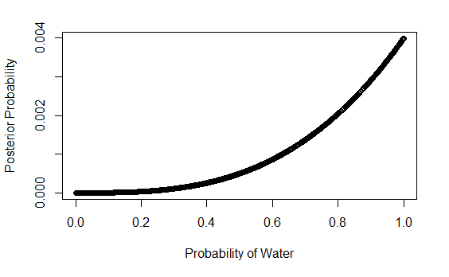

```r
plot(p_grid, posterior, type="b",
     ylab="Posterior Probability",
     xlab = "Probability of Water")
```

2:

```r
#Grid approximation with 1000 points
prior <- rep(1, 1000)
p_grid <- seq(from=0, to=1, length.out = 1000)
likelihood <- dbinom(3, 4, prob = p_grid)
unstd.posterior <- prior * likelihood
posterior <- unstd.posterior / sum(unstd.posterior)
```

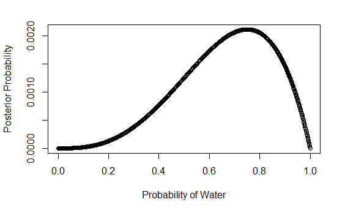

```r
plot(p_grid, posterior, type="b",
     ylab="Posterior Probability",
     xlab = "Probability of Water")
```

3:

```r
#Grid approximation with 1000 points
prior <- rep(1, 1000)
p_grid <- seq(from=0, to=1, length.out = 1000)
likelihood <- dbinom(5, 7, prob = p_grid)
unstd.posterior <- prior * likelihood
posterior <- unstd.posterior / sum(unstd.posterior)
```

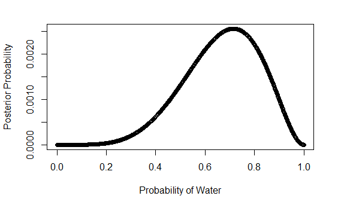

```r
plot(p_grid, posterior, type="b",
     ylab="Posterior Probability",
     xlab = "Probability of Water")
```

# 2M2

1:

```r
prior <- ifelse(p_grid < 0.5, 0, 1)
p_grid <- seq(from=0, to=1, length.out = 1000)
likelihood <- dbinom(3, 3, prob = p_grid)
unstd.posterior <- prior * likelihood
posterior <- unstd.posterior / sum(unstd.posterior)
```

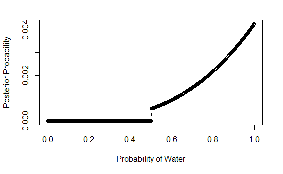

```r
plot(p_grid, posterior, type="b",
     ylab="Posterior Probability",
     xlab = "Probability of Water")
```

2:

```r
prior <- ifelse(p_grid < 0.5, 0, 1)
p_grid <- seq(from=0, to=1, length.out = 1000)
likelihood <- dbinom(3, 4, prob = p_grid)
unstd.posterior <- prior * likelihood
posterior <- unstd.posterior / sum(unstd.posterior)
```

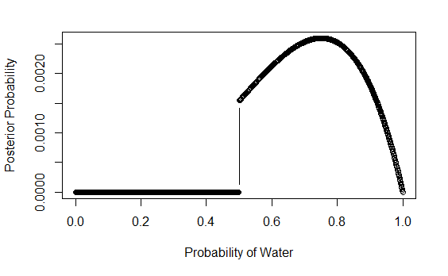

```r
plot(p_grid, posterior, type="b",
     ylab="Posterior Probability",
     xlab = "Probability of Water")
```

3:

```r
prior <- ifelse(p_grid < 0.5, 0, 1)
p_grid <- seq(from=0, to=1, length.out = 1000)
likelihood <- dbinom(5, 7, prob = p_grid)
unstd.posterior <- prior * likelihood
posterior <- unstd.posterior / sum(unstd.posterior)
```

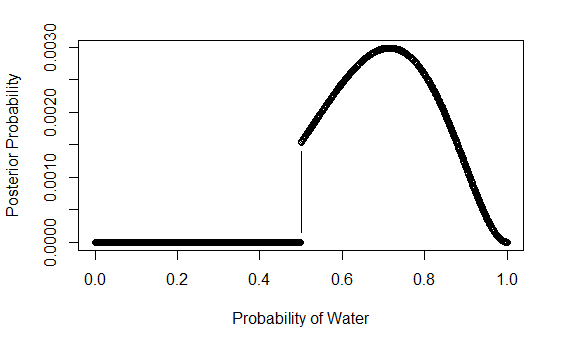

```r
plot(p_grid, posterior, type="b",
     ylab="Posterior Probability",
     xlab = "Probability of Water")
```

# 2M3

Pr(water|Earth) = 0.7 so Pr(land|Earth) = 0.3 Pr(land|Mars) = 1

Pr(Mars) = 0.5 Pr(Earth) = 0.5

We want Pr(Earth|land):

Pr(Earth|land) = Pr(land|Earth) * Pr(Earth) / Pr(land)

which expands to:

Pr(Earth|land) = Pr(land|Earth) * Pr(Earth) / (Pr(land|Earth) * Pr(Earth) + Pr(land|Mars) * Pr(Mars))

which ends up being:

Pr(Earth|land) = 0.3 * 0.5 /(0.3 * 0.5 + 1 * 0.5)

```r
0.3 * 0.5 /(0.3 * 0.5 +1 * 0.5)
```

```
[1] 0.2307692
```

# 2M4

Card1: B/B Card2: B/W Card3: W/W

If we observed one black side up, there are 2 ways of producing the black side up if we pick the B/B card and one way if we pick the B/W card, so in total, 2 of 3 ways are consistent with the other side of the card being black. The answer is 2/3.

# 2M5

With an extra B/B card:

If we observe one black side up, there are 4 ways of producing the black side up (2 for each B/B card) and 1 for picking the B/W card. The total probability that the other side is black is thus: 4/5

# 2M6

Card1: B/B Card2: B/W Card3: W/W

Black sides are heavier than cards with white sides so it is less likely that a card with black sides is pulled from the bag.

There are still 2 ways for B/B to produce a black side up, 1 way for B/W and zero ways for W/W. But according to the prior information, there is 1 way to get the B/B card, 2 ways to get the B/W card and 3 ways to get the W/W card so:

The total ways for the B/B card to produce a black side up are 2 * 1 and the total ways for the B/W card to produce a black side up are 1 * 2.

So, there are 4 ways total to see a black side up and 2 of these come from the B/B card so:

```r
2/4
```

```
[1] 0.5
```